# 41. 順序ロジスティック回帰分析

Masahiko Asano

2025-09-02

```r
library(MASS)
library(dplyr)
library(broom)
library(modelsummary)
library(stringr)
```

# 1. 順序ロジスティック回帰分析とは

- `Ordered Logistic Regression`のこと
- 順序尺度（例：1=反対、2=中立、3=賛成）のようにカテゴリーに自然な順序はあるが間隔は等間隔とは限らないデータに使う手法
- Rでは主に MASS パッケージの `polr()` 関数がよく使われる

## 1.1 データ

- ここでは自民党総裁選に関する架空のデータ (df) を作成する

```r
# -------------------------
# 1. データのシミュレーション
# -------------------------
N <- 500
age <- rnorm(N, mean = 50, sd = 15)       # 年齢
female <- rbinom(N, 1, 0.5)               # 女性ダミー

# 潜在スコア（線形予測子）
# 年齢が高いほど賛成↑、女性はやや反対寄り↓
latent <- 0.05*age - 0.5*female + rnorm(N)

# カテゴリ閾値を設定
cuts <- c(-1, 1)

# 潜在スコアを3カテゴリに切る (反対=1, 中立=2, 賛成=3)
attitude <- cut(latent,
                breaks = c(-Inf, cuts, Inf),
                labels = c("反対","中立","賛成"),
                ordered_result = TRUE)

df <- data.frame(attitude, age, female)
```

| attitude | 自民党の総裁選を実施するかどうか（賛成、中立、反対）→ 従属変数 |
| --- | --- |
| age | 政治家の年齢 |
| femele | 政治家の性別（女性なら 1、男性なら 0） |

```r
DT::datatable(df) %>%
  DT::formatRound(columns = "age",
    digits = 0)
```

|  | attitude | age | female |
| --- | --- | --- | --- |
| 1 | 賛成 | 75.1406892755616 | 1 |
| 2 | 賛成 | 63.57334856579131 | 1 |
| 3 | 賛成 | 53.64833754362611 | 0 |
| 4 | 中立 | 27.28241322247911 | 1 |
| 5 | 中立 | 23.34601566102669 | 1 |
| 6 | 賛成 | 64.99275481013046 | 1 |
| 7 | 賛成 | 41.42706278110927 | 0 |
| 8 | 賛成 | 32.09033061302095 | 1 |
| 9 | 中立 | 31.58651676308448 | 1 |
| 10 | 賛成 | 45.53379620919713 | 1 |

[output cut: 490 more lines]

## 1.2 順序ロジスティック回帰モデル式

- ここで想定する順序ロジスティック回帰モデル（累積ロジットモデル）は次のとおり
- 順序ロジスティック回帰（cumulative logit model）

#### 一般式（累積ロジット）

#### $$η = \beta_{age} age + \beta_{female}female$$

##### 2 つの累積ロジット（cutpoint は $\alpha_1, \alpha_2$）

#### $$logit[{P(Y≤j|X)}]= \theta_j - η,$$

##### $$logit[P(attitude ≦ 反対|age, female)]= \alpha_1 -η,$$

##### $$logit[P(attitude ≦ 中立|age, female)]= \alpha_2 -η,$$

- 累積ロジットはカテゴリ数が J の場合、cutpoint数は `J-1` 個
- ここでは従属変数 (attitude) が 3 カテゴリ（反対 < 中立 < 賛成）あり  
  → cutpoint数は 2 個  
  → 累積ロジット（`cumulative logit`）は 2 つ
- それぞれ「あるカテゴリ以下である確率」に対してロジットをとる

##### 1 本目のロジット（cutpoint α₁）

→「反対 vs （中立 or 賛成）」を区切る境界  
→ 反対以下である確率

##### $$logit[P(Y ≦ 反対)] = \alpha_1 -\beta_{age}age - \beta_{female}female$$

##### 2 本目のロジット（cutpoint α₂）

→「（反対 or 中立） vs 賛成」を区切る境界  
→ 反対〜中立である確率

##### $$logit[P(Y ≦ 中立)] = \alpha_2 -\beta_{age}age - \beta_{female}female$$

βの係数にデフォルトでマイナスがついている理由

・分析結果の解釈を容易にするため

##### 分析結果であるβの係数が

・プラスなら「上のカテゴリに行きやすい」  
・マイナスなら「下のカテゴリに留まりやすい」  
と解釈できる

- $Y$ = 態度（総裁選開催に反対=1, 中立=2, 賛成=3）
- $j$ = カテゴリの閾値（ここでは「反対|中立」「中立|賛成」の2つ）
- $\alpha_j$ = カテゴリごとの切片 (threshold)
- $\beta$ = 説明変数の係数：＋なら上のカテゴリ（＝「賛成寄り」）になりやすい
- 順序ロジットでは、カテゴリが順序を持っていることを前提にしている
- もし従属変数 (attitude) の値が単なる factor（unordered）だと「賛成、中立、反対」が「赤・青・黄」と同じ扱いになる  
  → 順序関係が無視されてしまう  
  → ここでは `反対 < 中立 < 賛成` という順序を明示的に与えてみる.  
  → `mutate()`関数を使ってで `attitude` を「順序付き因子（ordered factor）」に作り直す
- female もファクターに変換

```r
# データ & モデル（例）
df <- df |>
  mutate(
    attitude  = factor(attitude, levels = c("反対","中立","賛成"),
      ordered = TRUE),
    female = factor(female)
  )
```

## 1.3 順序ロジスティック回帰分析

```r
m1 <- polr(attitude ~ age + female,
  data = df,
  Hess = TRUE)
```

[figure not shown]

- 順序ロジスティック回帰分析では、同じデータでも分析のたびに係数の値が異なる

#### その理由：

- 順序ロジスティック回帰では、閾値（`cutpoint`, `threshold`）と係数が同時に推定されるため  
  → サンプルごとの分布の偏りによって `cutpoint` の位置が変動する  
  → それが係数推定にも影響する  
  → 係数そのものより「限界効果」や「予測確率の変化」で解釈する
- ここでは `log-odds`、`オッズ比`、限界効果と予測確率、それぞれの解釈方法を解説する

## 1.4 結果の解釈（log-odds）

#### 推定結果を累積ロジット式と線形予測子に当てはめてみる

##### ここで得られた係数値は `log-odds`

- $\beta_{age} = 0.09111$
- $\beta_{female} = -1.12218$

##### カット点:

- $\theta_{反対|中立} = -2.5149$
- $\theta_{中立|賛成} = 1.8682$

$$= -2.5149 - 0.09111・age +
1.12218・female\\→「反対\ vs \
（中立＋賛成）」のオッズのロジットを表す$$

$$= 1.8682 - 0.09111・age +
1.12218・female\\→「(反対＋中立)\
vs\ 賛成」のオッズのロジットを表す$$

##### 線形予測子: η（イータ）

- 「線形予測子」とは「累積ロジット式の右辺で、説明変数をまとめる部分」のこと
- 線形予測子 η 自体は「ただの線形結合」で、まだ確率ではない

#### $$η = \beta_{age} age + \beta_{female}female$$

#### $$η = 0.09111・age -1.12218・female$$

- ここで得られた線形予測子の `age` と `female` の回帰係数は `log(odds)` = `log-odds` = `logit`

#### この結果からわかること

まとめ

・`age` の係数 = 0.09111 → 0 より大きい  
→ 年齢が高いほど上のカテゴリ（=「賛成」）に移りやすい  
・`female` の係数 = -1.12218 → 0 より小さい  
→ 女性は男性に比べて下のカテゴリ（=「反対」）に移りやすい  
・これ以上の解釈はできない

## 1.5 結果の解釈（オッズ比）

- `log(odds)` を `exp()` してオッズ比に変換すると「どれくらい高いカテゴリに行きやすいか」を直感的に説明できる
- 例えば、age の係数 (0.09111) をオッズ比に変換してみる

```r
exp(0.09111)
```

```
[1] 1.095389
```

- `broom`パッケージの `broom()`関数を使って、`age` と `female` 両方の変数を同時にオッズ比に変換する

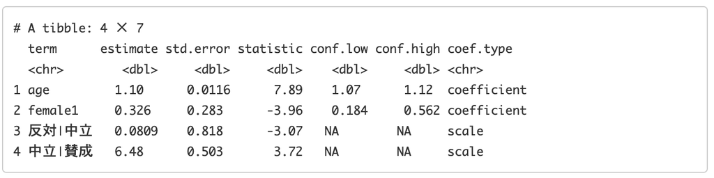

#### 各係数の解釈

##### age のオッズ比が 1.10

→ 年齢が1歳上がるごとに  
・「反対 → 中立・賛成に入るオッズ」  
・「反対・中立 → 賛成に入るオッズ」

の両方が約 1.1 倍（＝10%増加）する、という意味

##### female のオッズ比が 0.326

→ 女性だと  
・「反対 → 中立・賛成に入るオッズ」  
・「反対・中立 → 賛成に入るオッズ」

の両方が約 0.33 倍（＝67%減少）する、という意味

まとめ

・年齢が 1 歳増えると「賛成」寄りになるオッズが約 10 %増加  
→ 高齢ほど賛成しやすい  
・女性は男性に比べて「賛成」寄りになるオッズが約 67 %低下  
→ 女性は反対・中立寄り

## 1.6 結果の解釈（予測確率と限界効果）

- オッズ比を使った解釈に加えて、予測確率を示すと理解しやすい
- 線形予測子 η を使って「閾値 $\alpha_k$ 」と比較することで、各カテゴリの確率を計算する
- ここでは、男女別に自民党候補者が総裁選開催に関して反対、中立、賛成する予測確率を可視化してみる

#### 予測確率の推移（性別ごと）

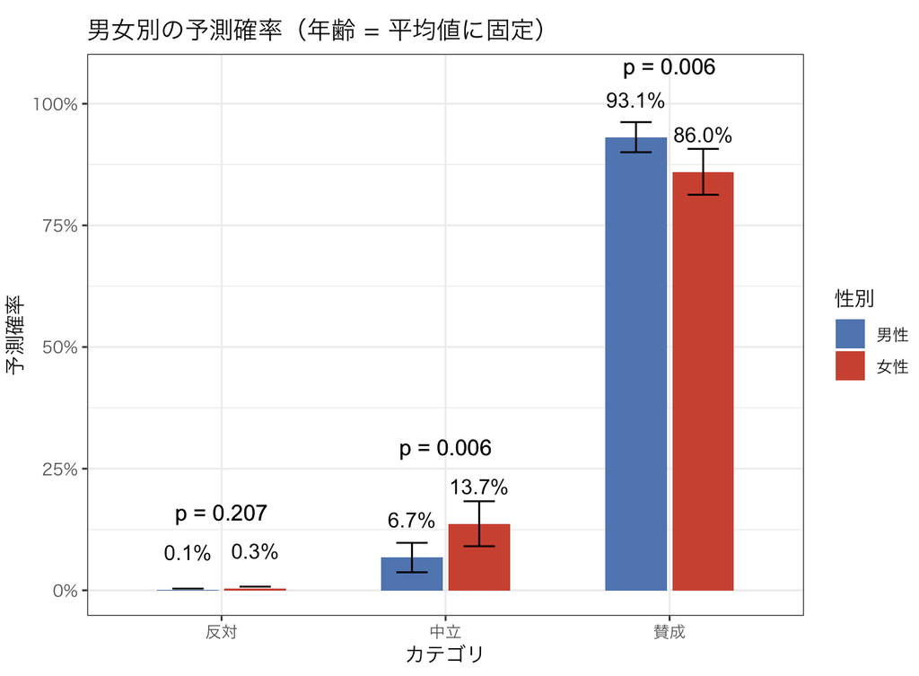

```r
# 必要パッケージ
library(MASS)
library(ordinal)
library(dplyr)
library(tidyr)
library(ggplot2)
library(scales)
library(marginaleffects)

# ========= 前処理 & 推定（既にfit/df_cleanがあればスキップ可） =========
options(contrasts = c("contr.treatment","contr.poly"))

df_clean <- df %>%
  transmute(
    attitude = factor(attitude, levels = c("反対","中立","賛成"), ordered = TRUE),
    age      = as.numeric(age),
    female   = factor(female, levels = c(0,1), labels = c("男性","女性"))
  ) %>%
  filter(complete.cases(across(everything()))) %>%
  droplevels()

stopifnot(all(table(df_clean$attitude) > 0), all(table(df_clean$female) > 0))
cats <- levels(df_clean$attitude)

fit <- try(polr(attitude ~ age + female, data = df_clean, Hess = TRUE), silent = TRUE)
if (inherits(fit, "try-error")) {
  fit <- clm(attitude ~ age + female, data = df_clean, link = "logit")
  fit_engine <- "clm"
} else {
  fit_engine <- "polr"
}

# ========= 男女別の予測確率（年齢=平均に固定） =========
mean_age <- mean(df_clean$age, na.rm = TRUE)
newdat <- data.frame(age = mean_age, female = c("男性","女性"))

# 予測確率＋95%CI
preds <- predictions(
  fit,
  newdata = newdat,
  type = if (inherits(fit,"clm")) "prob" else "probs"
)

# カテゴリ列の自動検出
detect_cat_col <- function(d, cats){
  cand <- intersect(names(d),
                    c("category","response","response.level","response_level",
                      "outcome","term","level","type","group"))
  for(nm in cand){
    v <- as.character(d[[nm]])
    if (all(v %in% cats)) return(nm)
  }
  chr <- names(d)[sapply(d, function(x) is.character(x) || is.factor(x))]
  for(nm in chr){
    v <- as.character(d[[nm]])
    if (all(v %in% cats)) return(nm)
  }
  NA_character_
}
cat_col <- detect_cat_col(preds, cats)
if (is.na(cat_col)) stop("カテゴリ列が特定できませんでした（predictions 出力）。")

preds_df <- preds %>%
  rename(category = !!cat_col) %>%
  mutate(
    category = factor(as.character(category), levels = cats, ordered = TRUE),
    female   = factor(female, levels = c("男性","女性")),
    label    = percent(estimate, accuracy = 0.1)
  )

# ========= 女性−男性の確率差（カテゴリ別）と p値 =========
comp <- comparisons(
  fit,
  variables = list(female = c("男性","女性")), # 上−下 = 女性−男性
  newdata   = newdat,
  type      = if (inherits(fit,"clm")) "prob" else "probs"
)
cat_col2 <- detect_cat_col(comp, cats)
if (is.na(cat_col2)) stop("カテゴリ列が特定できませんでした（comparisons 出力）。")

comp_out <- comp %>%
  rename(category = !!cat_col2) %>%
  mutate(category = factor(as.character(category), levels = cats, ordered = TRUE)) %>%
  select(category, estimate, conf.low, conf.high, p.value)

# p値表示用データ（各カテゴリのバーの上に置く）
p_labels <- preds_df %>%
  group_by(category) %>%
  summarise(y = min(0.98, max(estimate) + 0.06), .groups = "drop") %>%
  left_join(comp_out, by = "category") %>%
  mutate(p_text = paste0("p = ", formatC(p.value, format = "f", digits = 3)))

# ========= グラフ：棒＋95%CI＋数値ラベル＋p値（カテゴリごと上部） =========
res_gender_ci_p <- ggplot(preds_df, aes(x = category,
  y = estimate,
  fill = female)) +
  geom_col(position = position_dodge(width = 0.6), width = 0.55) +
  geom_errorbar(aes(ymin = conf.low, ymax = conf.high),
                position = position_dodge(width = 0.6), width = 0.28) +
  geom_text(aes(label = label),
            position = position_dodge(width = 0.6), vjust = -2, size = 4) +
  # 各カテゴリの中央に p値を注記（男女差：女性−男性）
  geom_text(data = p_labels,
            aes(x = category, y = y, label = p_text),
            inherit.aes = FALSE, vjust = -2.5, size = 4.2) +
  scale_fill_manual(values = c("男性"="#4575b4","女性"="#d73027")) +
  scale_y_continuous(labels = percent_format(accuracy = 1), limits = c(0, 1.05)) +
  labs(
    title = sprintf("男女別の予測確率（年齢 = 平均値に固定）", fit_engine),
    x = "カテゴリ", y = "予測確率", fill = "性別"
  ) +
  theme_minimal(base_size = 14)　+
  theme_bw(base_family = "HiraKakuProN-W3")

res_gender_ci_p
```

結果の解釈（まとめ）  
横軸：態度のカテゴリ（反対 → 中立 → 賛成）  
縦軸：そのカテゴリを選ぶ確率（%）

#### 1.4 結果の解釈（`log-odds`）:

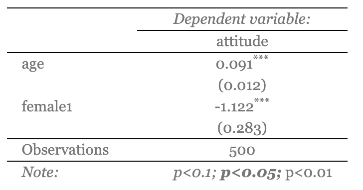

- Note 1: 係数は `log-odds`
- Note 2: `female1` の意味は「female の値は女性が 1、男性が 0」

・`female` の `log-odds = -1.122`  
→ 0 より小さい  
→ 女性は男性に比べて「反対」寄りになりやすい  
→ 統計的に有意

#### 1.5 結果の解釈（オッズ比）:

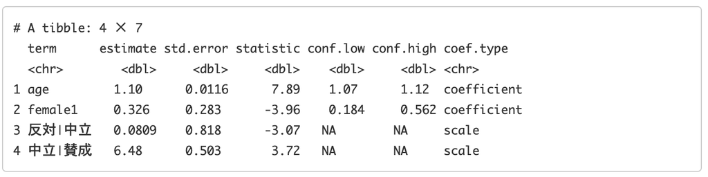

・`female` の `odds比 = 0.326`  
→ 女性は男性に比べて「賛成」寄りになるオッズが約 67 %低下  
→ 女性は反対・中立寄り

#### 1.6 結果の解釈（予測確率と限界効果）：

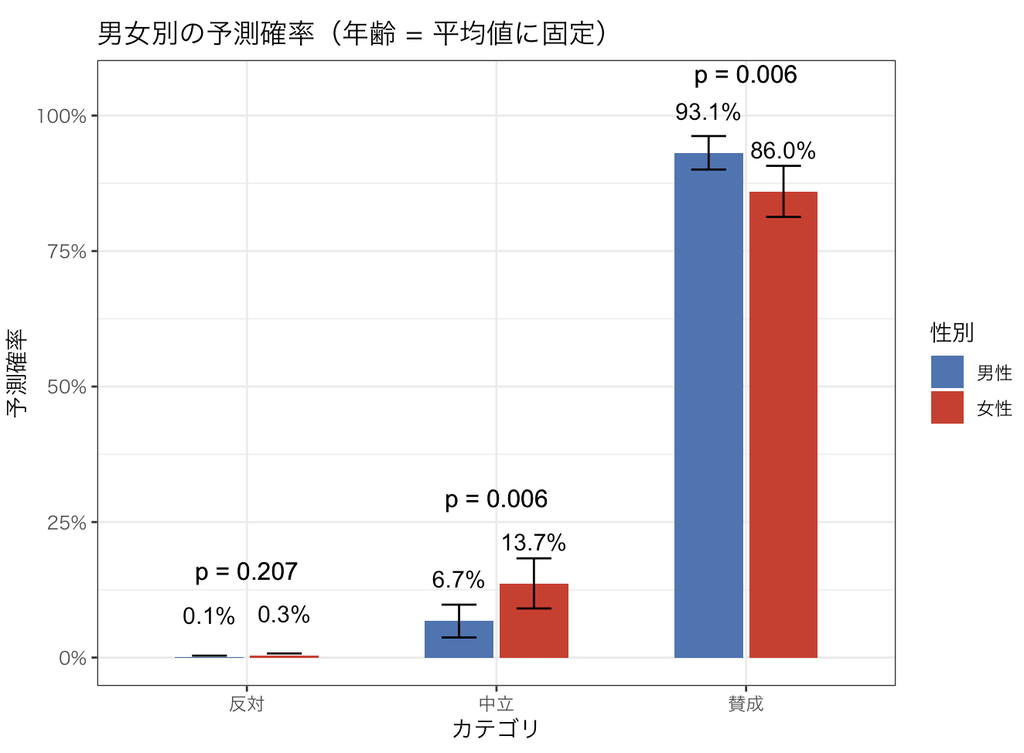

###### 賛成:

・男性の予測確率 (93.1%)  
・女性の予測確率 (86.0%)  
→ 女性ダミーの限界効果 = 7.1%ポイント  
→ 差は大きく、p値も有意 (p = 0.006)

###### 反対:

・男性の予測確率 (0.1%)  
・女性の予測確率 (0.3%)  
→ 差は小さく、p値は有意ではない (p = 0.207)

#### → 1.4, 1.5, 1.6 の結果が一致していることがわかる

**参考文献**

飯田健『計量政治分析』共立出版、2013年.

[宋財泫 (Jaehyun Song)・矢内勇生 (Yuki Yanai)「私たちのR: ベストプラクティスの探究」](https://www.jaysong.net/RBook/)

浅野正彦, 矢内勇生.『Rによる計量政治学』オーム社、2018年

浅野正彦, 中村公亮.『初めてのRStudio』オーム社、2018年

Winston Chang, R Graphics Cookbook, O’Reilly Media, 2012.

Kieran Healy, DATA VISUALIZATION, Princeton, 2019

Kosuke Imai, Quantitative Social Science: An Introduction, Princeton University Press, 2017